# Data analysis of mollusks and echinoderms abundance

Claudia Campanini

2022-06-21

# 1 INTRODUCTION

Mollusk and echinoderm abundance by class extracted by analyzing photos collected on belt transects during surveys at different sites along Okinawa and Aka Island. Belt transect area (1 replicate) was 25 m<sup>2</sup> for mollusks and 50 m^2 for echinoderms. Sites exposure to anthropogenic pressure was previously estimated using the scale from DiBattista et al., 2019.

```r
#load libraries
library(here)
library(dplyr)
library(ggplot2)
library(readxl)   # to import excel datasets
library(magrittr)
```

# 2 Mollusks | Abundance estimates

Merge raw files from each site in a single data frame

```r
mol_raw <-  list.files(path = here("Multi-taxa_data","MollEchino","Mol_raw"),
             pattern = "*.xlsx",
             full.names =T) %>%
  sapply(read_excel,
         simplify = F,
         USE.NAMES = F)

names(mol_raw) = c("HI", "S1", "S2", "ZP", "ZA", "YO", "MI","SK", "SN", "AW", "G1", "G2")

mol_raw_df <- as.data.frame(do.call(rbind, mol_raw))
str(mol_raw_df)
```

```
## 'data.frame':    1497 obs. of  11 variables:
##  $ transect  : chr  "AW_D1" "AW_D1" "AW_D2" "AW_D2" ...
##  $ site      : chr  "AW" "AW" "AW" "AW" ...
##  $ depth     : chr  "Deep" "Deep" "Deep" "Deep" ...
##  $ site_depth: chr  "AW_D" "AW_D" "AW_D" "AW_D" ...
##  $ PHOTO     : chr  "P5260007" "P5260008" "P5260012" "P5260016" ...
##  $ DIVER     : chr  "HM" "HM" "HM" "HM" ...
##  $ CLASS     : chr  "Gastropoda" "Gastropoda" "Gastropoda" "Bivalvia" ...
##  $ GENUS     : chr  NA NA NA NA ...
##  $ SPECIES   : logi  NA NA NA NA NA NA ...
##  $ NOTES     : chr  "Nudibranchia" "Nudibranchia" "Nudibranchia" NA ...
##  $ SIZE (cm) : chr  "5" "4" "7" "4" ...
```

```r
rm(mol_raw)
```

Format the data frame for analysis

```r
mol_raw_df$CLASS <- replace(mol_raw_df$CLASS,mol_raw_df$CLASS=="-",NA)
mol_raw_df[,c(1:4,7)] <- lapply(mol_raw_df[,c(1:4,7)], as.factor)
mol_raw_df$site <-ordered(mol_raw_df$site,levels=c("HI", "S1", "S2", "ZP", "ZA", "YO", "MI","SK", "SN", "AW", "G1", "G2"))
mol_raw_df[,11] <- as.numeric(mol_raw_df[,11])
str(mol_raw_df)
```

```
## 'data.frame':    1497 obs. of  11 variables:
##  $ transect  : Factor w/ 66 levels "AW_D1","AW_D2",..: 1 1 2 2 3 3 3 3 3 3 ...
##  $ site      : Ord.factor w/ 12 levels "HI"<"S1"<"S2"<..: 10 10 10 10 10 10 10 10 10 10 ...
##  $ depth     : Factor w/ 2 levels "Deep","Shallow": 1 1 1 1 1 1 1 1 1 1 ...
##  $ site_depth: Factor w/ 23 levels "AW_D","AW_S",..: 1 1 1 1 1 1 1 1 1 1 ...
##  $ PHOTO     : chr  "P5260007" "P5260008" "P5260012" "P5260016" ...
##  $ DIVER     : chr  "HM" "HM" "HM" "HM" ...
##  $ CLASS     : Factor w/ 3 levels "Bivalvia","Cephalopoda",..: 3 3 3 1 3 1 1 3 3 1 ...
##  $ GENUS     : chr  NA NA NA NA ...
##  $ SPECIES   : logi  NA NA NA NA NA NA ...
##  $ NOTES     : chr  "Nudibranchia" "Nudibranchia" "Nudibranchia" NA ...
##  $ SIZE (cm) : num  5 4 7 4 2 4.5 5 5 4 1.5 ...
```

Extract abundance by class per transect (replicate) from the data frame

```r
library(tidyr) #to use the "separate" function
library(janitor) #to use the tabyl function
mol_raw_df <- mol_raw_df[!is.na(mol_raw_df$transect),]

mol_class <- mol_raw_df[!is.na(mol_raw_df$CLASS),] %>% tabyl(transect, CLASS, show_missing_levels = FALSE)
```

Add empty lines for transects with no records

```r
str(mol_class)
```

```
## Classes 'tabyl' and 'data.frame':    66 obs. of  4 variables:
##  $ transect   : Factor w/ 66 levels "AW_D1","AW_D2",..: 1 2 3 4 5 6 7 8 9 10 ...
##  $ Bivalvia   : num  0 1 4 3 13 2 5 0 1 0 ...
##  $ Cephalopoda: num  0 0 0 0 0 0 0 0 0 0 ...
##  $ Gastropoda : num  2 1 5 5 0 3 6 3 7 4 ...
##  - attr(*, "core")='data.frame': 66 obs. of  4 variables:
##   ..$ transect   : Factor w/ 66 levels "AW_D1","AW_D2",..: 1 2 3 4 5 6 7 8 9 10 ...
##   ..$ Bivalvia   : num [1:66] 0 1 4 3 13 2 5 0 1 0 ...
##   ..$ Cephalopoda: num [1:66] 0 0 0 0 0 0 0 0 0 0 ...
##   ..$ Gastropoda : num [1:66] 2 1 5 5 0 3 6 3 7 4 ...
##  - attr(*, "tabyl_type")= chr "two_way"
##  - attr(*, "var_names")=List of 2
##   ..$ row: chr "transect"
##   ..$ col: chr "CLASS"
```

```r
mol_class$transect <- as.character(mol_class$transect)
mol_class <- rbind(mol_class,
                   c("AW_S3", 0, 0 , 0),
                   c("S2_D1", 0, 0 , 0),
                   c("G1_D3", 0, 0 , 0))
```

Add site_depth column and remove “Cephalopoda”

```r
mol_class <- mol_class %>%
  separate(transect, c("site", "depth_rep")) %>%
  mutate(transect = mol_class$transect )

mol_class$depth <- gsub("[[:digit:]]", "", mol_class$depth_rep) #remove the number from depth_rep from Alphanumeric Character String Using gsub() Function

mol_class <- mol_class %>%
  mutate(site_depth = paste(site, depth, sep='_'))

mol_class$depth_rep <- NULL
mol_class$Cephalopoda <- NULL
```

Add pressure score column and define the appropriate class for each column

```r
mol_class <- mol_class %>%
       mutate(pressure = case_when(site == 'HI' |
                                   site == "S1" |
                                   site == "S2" ~ "Low",
                                   site == "ZP" |
                                   site == 'ZA' |
                                   site == "YO" |
                                   site == "MI" ~ "Medium",
                                   site == 'SK' |
                                   site == 'SN' |
                                   site == "AW" |
                                   site == "G1" |
                                   site == "G2"~ "High"))

mol_class <- mol_class[,c(4,1,5:7,2:3)] #re-order columns

mol_class$pressure <- ordered(mol_class$pressure, levels=c("Low","Medium", "High"))
mol_class$site <-ordered(mol_class$site,levels=c("HI", "S1", "S2", "ZP", "ZA", "YO", "MI","SK", "SN", "AW", "G1", "G2"))
mol_class[,2:4] <- lapply(mol_class[,2:4], as.factor)
mol_class[,6:7] <- lapply(mol_class[,6:7], as.numeric)

str(mol_class)
```

```
## 'data.frame':    69 obs. of  7 variables:
##  $ transect  : chr  "AW_D1" "AW_D2" "AW_D3" "AW_S1" ...
##  $ site      : Ord.factor w/ 12 levels "HI"<"S1"<"S2"<..: 10 10 10 10 10 11 11 11 11 11 ...
##  $ depth     : Factor w/ 2 levels "D","S": 1 1 1 2 2 1 1 2 2 2 ...
##  $ site_depth: Factor w/ 23 levels "AW_D","AW_S",..: 1 1 1 2 2 3 3 4 4 4 ...
##  $ pressure  : Ord.factor w/ 3 levels "Low"<"Medium"<..: 3 3 3 3 3 3 3 3 3 3 ...
##  $ Bivalvia  : num  0 1 4 3 13 2 5 0 1 0 ...
##  $ Gastropoda: num  2 1 5 5 0 3 6 3 7 4 ...
```

# 3 Mollusks | Abundance by class by depth within site

## 3.1 Create the input dataframe

Standard deviation will be used to add error bars to the bar plot.

```r
mol_mean <- mol_class %>%
  group_by(site_depth,site,depth,pressure) %>%
  reframe(Biv_mean=round(mean(Bivalvia),0),
            Gas_mean=round(mean(Gastropoda),0),
            Biv_sd=round(sd(Bivalvia),0),
            Gas_sd=round(sd(Gastropoda),0))
```

https://seananderson.ca/2013/10/19/reshape/

```r
library(reshape2)
mol_mean_long <- melt(mol_mean[,1:6], id.vars = c("site_depth","site","depth","pressure"),
  variable.name = "class",
  value.name = c("mean"))

mol_sd_long <- melt(mol_mean[,c("site_depth","Biv_sd","Gas_sd")], id.vars = c("site_depth"),
  variable.name = "class",
  value.name = c("sd"))

mol_mean_bar <- cbind(mol_mean_long,mol_sd_long$sd)
mol_mean_bar
```

```
##    site_depth site depth pressure    class mean mol_sd_long$sd
## 1        AW_D   AW     D     High Biv_mean    2              2
## 2        AW_S   AW     S     High Biv_mean    5              7
## 3        G1_D   G1     D     High Biv_mean    2              3
## 4        G1_S   G1     S     High Biv_mean    0              1
## 5        G2_D   G2     D     High Biv_mean   14              6
## 6        G2_S   G2     S     High Biv_mean    1              1
## 7        HI_D   HI     D      Low Biv_mean    7              6
## 8        HI_S   HI     S      Low Biv_mean   14              6
## 9        MI_D   MI     D   Medium Biv_mean    1              1
## 10       MI_S   MI     S   Medium Biv_mean    8              3
## 11       S1_D   S1     D      Low Biv_mean   18              4
## 12       S1_S   S1     S      Low Biv_mean   12              4
## 13       S2_D   S2     D      Low Biv_mean   12             15
## 14       S2_S   S2     S      Low Biv_mean   10              3
```

[output cut: 32 more lines]

```r
mol_mean_bar <- mol_mean_bar %>%
  mutate(class = case_when(class == 'Biv_mean' ~ "Bivalvia",
                           class == "Gas_mean"~ "Gastropoda")) %>% #replace class values with class names
  rename(sd = `mol_sd_long$sd`) #rename sd column


mol_mean_bar$phylum <- "Mollusca" # add the phylum column
mol_mean_bar$phylum <- as.factor(mol_mean_bar$phylum ) #
mol_mean_bar <- mol_mean_bar[,c(1:4,8,5:7)] #re-order columns

rm(mol_mean_long, mol_sd_long)
```

# 4 Echinoderms | Abundance estimates

Merge raw files from each site in a single data frame

```r
ech_raw <-  list.files(path = here("Multi-taxa_data","MollEchino","Ech_raw"),
             pattern = "*.xlsx",
             full.names =T) %>%
  lapply(read_excel) %>%
  bind_rows
```

Format the data frame for analysis

```r
ech_raw$CLASS <- replace(ech_raw$CLASS,ech_raw$CLASS=="-",NA)
ech_raw[,c(1:4,7)] <- lapply(ech_raw[,c(1:4,7)], as.factor)
ech_raw$site <-ordered(ech_raw$site,levels=c("HI", "S1", "S2", "ZP", "ZA", "YO", "MI","SK", "SN", "AW", "G1", "G2"))
str(ech_raw)
```

```
## tibble [6,246 × 11] (S3: tbl_df/tbl/data.frame)
##  $ transect  : Factor w/ 69 levels "AW_D1","AW_D2",..: 1 1 1 1 1 1 1 1 1 1 ...
##  $ site      : Ord.factor w/ 12 levels "HI"<"S1"<"S2"<..: 10 10 10 10 10 10 10 10 10 10 ...
##  $ depth     : Factor w/ 2 levels "Deep","Shallow": 1 1 1 1 1 1 1 1 1 1 ...
##  $ site_depth: Factor w/ 23 levels "AW_D","AW_S",..: 1 1 1 1 1 1 1 1 1 1 ...
##  $ PHOTO     : chr [1:6246] "GOPR2847" "GOPR2848" "GOPR2849" "GOPR2850" ...
##  $ DIVER     : chr [1:6246] "AA" "AA" "AA" "AA" ...
##  $ CLASS     : Factor w/ 5 levels "Asteroidea","Crinoidea",..: 3 3 3 3 3 2 3 3 3 3 ...
##  $ GENUS     : logi [1:6246] NA NA NA NA NA NA ...
##  $ SPECIES   : logi [1:6246] NA NA NA NA NA NA ...
##  $ NOTES     : chr [1:6246] NA NA NA NA ...
##  $ SIZE (cm) : chr [1:6246] "2.0" "1.0" "1.0" "1.0" ...
```

```r
levels(ech_raw$CLASS)
```

```
## [1] "Asteroidea"    "Crinoidea"     "Echinoidea"    "Holothuroidea"
## [5] "Ophiuroidea"
```

Extract abundance by class per transect (replicate) from the dataframe

```r
library(tidyr) #to use the "separate" function
library(janitor) #to use the tabyl function

ech_raw <- ech_raw[!is.na(ech_raw$transect),]

ech_class <- ech_raw[!is.na(ech_raw$CLASS),] %>%
  tabyl(transect, CLASS, show_missing_levels = FALSE)

ech_class <- ech_class %>%
  separate(transect, c("site", "depth_rep")) %>%
  mutate(transect = ech_class$transect )

ech_class$depth <- gsub("[[:digit:]]", "", ech_class$depth_rep) #remove the number from depth

# Remove Numbers from Alphanumeric Character String Using gsub() Function
ech_class <- ech_class %>%
  mutate(site_depth = paste(site, depth, sep='_')) %>%
  dplyr::select(-depth_rep) #remove depth_rep
```

Add pressure score column

```r
ech_class <- ech_class %>%
       mutate(pressure = case_when(site == 'HI' |
                                   site == "S1" |
                                   site == "S2" ~ "Low",
                                   site == "ZP" |
                                   site == 'ZA' |
                                   site == "YO" |
                                   site == "MI" ~ "Medium",
                                   site == 'SK' |
                                   site == 'SN' |
                                   site == "AW" |
                                   site == "G1" |
                                   site == "G2"~ "High"))

ech_class <- ech_class[,c(7,1,8:10,2:6)]  #re-ordering the column
ech_class$pressure <- ordered(ech_class$pressure, levels=c("Low","Medium", "High"))

ech_class$site <-ordered(ech_class$site,levels=c("HI", "S1", "S2", "ZP", "ZA", "YO", "MI","SK", "SN", "AW", "G1", "G2"))

ech_class[,3:5] <- lapply(ech_class[,3:5], as.factor)

str(ech_class)
```

```
## 'data.frame':    69 obs. of  10 variables:
##  $ transect     : Factor w/ 69 levels "AW_D1","AW_D2",..: 1 2 3 4 5 6 7 8 9 10 ...
##  $ site         : Ord.factor w/ 12 levels "HI"<"S1"<"S2"<..: 10 10 10 10 10 10 11 11 11 11 ...
##  $ depth        : Factor w/ 2 levels "D","S": 1 1 1 2 2 2 1 1 1 2 ...
##  $ site_depth   : Factor w/ 23 levels "AW_D","AW_S",..: 1 1 1 2 2 2 3 3 3 4 ...
##  $ pressure     : Ord.factor w/ 3 levels "Low"<"Medium"<..: 3 3 3 3 3 3 3 3 3 3 ...
##  $ Asteroidea   : num  3 1 1 1 1 0 1 1 0 1 ...
##  $ Crinoidea    : num  6 0 10 7 12 0 0 2 3 80 ...
##  $ Echinoidea   : num  40 56 27 310 300 263 0 0 1 7 ...
##  $ Holothuroidea: num  2 2 0 0 2 0 4 2 0 0 ...
##  $ Ophiuroidea  : num  0 0 0 0 0 0 0 0 0 0 ...
```

# 5 Echinoderms | Abundance by class by depth within site

## 5.1 Create the input dataframe

Adjust `ech_class` to create a new input dataframe for the barplot. Include a column with - mean echinoderm abundance by class per depth within site among replicates; - standard deviation by class per depth within site among replicates.

Standard deviation will be used to add error bars to the barplot.

```r
ech_mean <- ech_class %>%
  group_by(site_depth,site,depth,pressure) %>%
  reframe(Ast_mean=round(mean(Asteroidea),0),
            Cri_mean=round(mean(Crinoidea),0),
            Ech_mean=round(mean(Echinoidea),0),
            Hol_mean=round(mean(Holothuroidea),0),
            Oph_mean=round(mean(Ophiuroidea),0),
            Ast_sd=round(sd(Asteroidea),0),
            Cri_sd=round(sd(Crinoidea),0),
            Ech_sd=round(sd(Echinoidea),0),
            Hol_sd=round(sd(Holothuroidea),0),
            Oph_sd=round(sd(Ophiuroidea),0),)
```

https://seananderson.ca/2013/10/19/reshape/

```r
library(reshape2)
ech_mean_long <- melt(ech_mean[,1:9], id.vars = c("site_depth","site","depth","pressure"),
  variable.name = "class",
  value.name = c("mean"))

ech_sd_long <- melt(ech_mean[,c(1,10:14)], id.vars = c("site_depth"),
  variable.name = "class",
  value.name = c("sd"))


ech_mean_bar <- cbind(ech_mean_long,ech_sd_long$sd)
ech_mean_bar
```

```
##     site_depth site depth pressure    class mean ech_sd_long$sd
## 1         AW_D   AW     D     High Ast_mean    2              1
## 2         AW_S   AW     S     High Ast_mean    1              1
## 3         G1_D   G1     D     High Ast_mean    1              1
## 4         G1_S   G1     S     High Ast_mean    0              1
## 5         G2_D   G2     D     High Ast_mean    1              1
## 6         G2_S   G2     S     High Ast_mean    1              1
## 7         HI_D   HI     D      Low Ast_mean    0              1
## 8         HI_S   HI     S      Low Ast_mean    1              1
## 9         MI_D   MI     D   Medium Ast_mean    0              1
## 10        MI_S   MI     S   Medium Ast_mean    2              1
## 11        S1_D   S1     D      Low Ast_mean    0              0
## 12        S1_S   S1     S      Low Ast_mean    0              1
## 13        S2_D   S2     D      Low Ast_mean    1              1
## 14        S2_S   S2     S      Low Ast_mean    0              1
```

[output cut: 101 more lines]

```r
ech_mean_bar <- ech_mean_bar %>%
  mutate(class = case_when(class == 'Ast_mean' ~ "Asteroidea",
                           class == "Cri_mean"~ "Crinoidea",
                           class == 'Ech_mean' ~ "Echinoidea",
                           class == "Hol_mean"~ "Holothuroidea",
                           class == 'Oph_mean' ~ "Ophiuroidea")) %>% #replace class values with class names
  rename(sd = `ech_sd_long$sd`) #rename sd column

ech_mean_bar$phylum <- "Echinodermata" # add the phylum column
ech_mean_bar$phylum <- as.factor(ech_mean_bar$phylum )

ech_mean_bar <- ech_mean_bar[,c(1:4,8,5:7)] #re-order columns

rm(ech_mean_long, ech_sd_long)
```

# 6 Invertebrates

## 6.1 Barplot with mollusk and echinoderm abundance by class by depth within site

```r
inv_bar <- rbind(mol_mean_bar,ech_mean_bar)
#library("writexl")
#write_xlsx(inv_bar,"C:/Users/claud/Documents/COMUNE/STUDIO.LAVORO/IMBRSea/Thesis/StatAnalysis/Multi-taxa_data/MollEchino/mol_ech_ab_class_output.xlsx")

str(inv_bar)
```

```
## 'data.frame':    161 obs. of  8 variables:
##  $ site_depth: Factor w/ 23 levels "AW_D","AW_S",..: 1 2 3 4 5 6 7 8 9 10 ...
##  $ site      : Ord.factor w/ 12 levels "HI"<"S1"<"S2"<..: 10 10 11 11 12 12 1 1 7 7 ...
##  $ depth     : Factor w/ 2 levels "D","S": 1 2 1 2 1 2 1 2 1 2 ...
##  $ pressure  : Ord.factor w/ 3 levels "Low"<"Medium"<..: 3 3 3 3 3 3 1 1 2 2 ...
##  $ phylum    : Factor w/ 2 levels "Mollusca","Echinodermata": 1 1 1 1 1 1 1 1 1 1 ...
##  $ class     : chr  "Bivalvia" "Bivalvia" "Bivalvia" "Bivalvia" ...
##  $ mean      : num  2 5 2 0 14 1 7 14 1 8 ...
##  $ sd        : num  2 7 3 1 6 1 6 6 1 3 ...
```

```r
inv_bar$class <- ordered(inv_bar$class,levels=c("Bivalvia", "Gastropoda","Asteroidea","Crinoidea","Echinoidea","Holothuroidea","Ophiuroidea"))

invPalette <- c("#56B4E9","#0072B2","#F0E442","#E69F00","#D55E00","#CC79A7","orchid3")
```

Ophiuroidea were removed from the plot because they were recorded only at one site

- scale= “free” –> https://stackoverflow.com/questions/18046051/setting-individual-axis-limits-with-facet-wrap-and-scales-free-in-ggplot2
- switch –> https://stackoverflow.com/questions/3261597/change-the-position-of-the-strip-label-in-ggplot-from-the-top-to-the-bottom#:~:text=As%20of%20ggplot2%202.0%2C%20the,be%20displayed%20to%20the%20left.
- strip.placement –> https://stackoverflow.com/questions/3261597/change-the-position-of-the-strip-label-in-ggplot-from-the-top-to-the-bottom#:~:text=As%20of%20ggplot2%202.0%2C%20the,be%20displayed%20to%20the%20left.

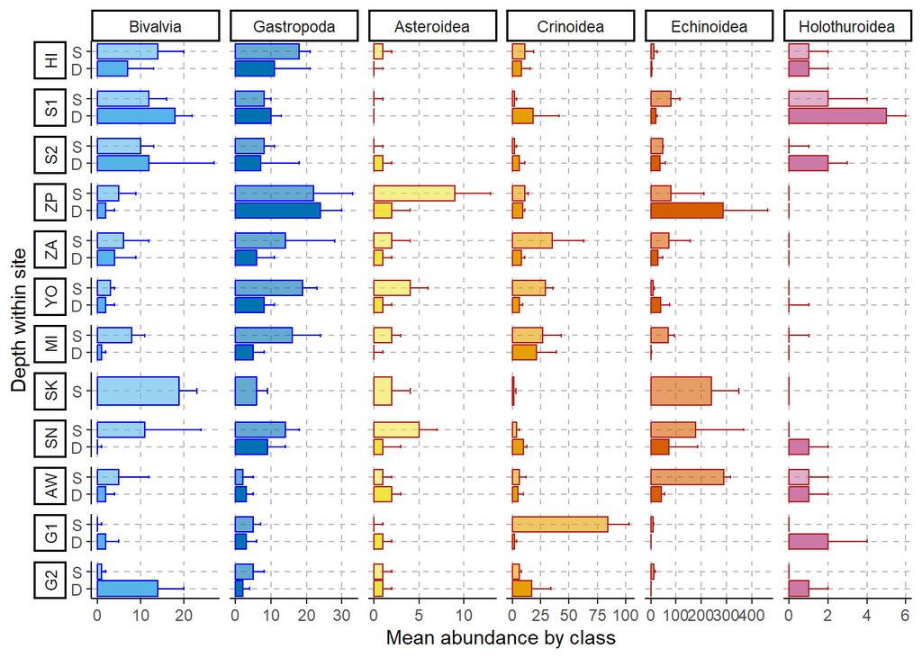

```r
ggplot(subset(inv_bar, inv_bar$class != "Ophiuroidea"),
       aes(x=depth, y=mean, fill=class, label=mean, color=phylum)) +
  geom_bar(aes(alpha=depth),position="dodge",stat="identity") +
  geom_errorbar(aes(ymin=mean, ymax=mean+sd), width=.2,
                 position="dodge")+
  facet_grid(site ~ class, scales = "free", switch = "y")+ # https://stackoverflow.com/questions/18046051/setting-individual-axis-limits-with-facet-wrap-and-scales-free-in-ggplot2
  theme_classic()+
  labs(x="Depth within site",
       y="Mean abundance by class")+
  scale_fill_manual(values=invPalette)+
  scale_color_manual(values=c("blue","firebrick"), guide ="none")+
  scale_alpha_manual(values=c(1,.6))+
  guides(fill="none", alpha= "none")+
  theme(panel.grid.major.x = element_line(color = "grey",
                                          size = 0.5,
                                          linetype = 2),
        panel.grid.major.y = element_line(color = "grey",
                                          size = 0.5,
                                          linetype = 2),
        strip.placement = "outside")+
  coord_flip()
```

Export plot

```r
ggsave("mol-ech_abundance_vert_barplot.tiff",
       units="in", width=7, height=6, dpi=300, compression = 'lzw',
       path = here ("Multi-taxa_data","MollEchino","Output"))
```

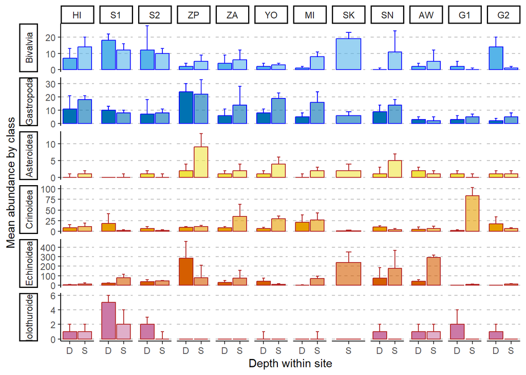

```r
ggplot(subset(inv_bar, inv_bar$class != "Ophiuroidea"),
       aes(x=depth, y=mean, fill=class, label=mean, color=phylum)) +
  geom_bar(aes(alpha=depth),position="dodge",stat="identity") +
  geom_errorbar(aes(ymin=mean, ymax=mean+sd), width=.2,
                 position="dodge")+
  facet_grid(class ~ site, scales = "free", switch = "y")+ # https://stackoverflow.com/questions/18046051/setting-individual-axis-limits-with-facet-wrap-and-scales-free-in-ggplot2
  theme_classic()+
  labs(x="Depth within site",
       y="Mean abundance by class")+
  scale_fill_manual(values=invPalette)+
  scale_color_manual(values=c("blue","firebrick"), guide ="none")+
  scale_alpha_manual(values=c(1,.6))+
  guides(fill="none", alpha= "none")+
  theme(panel.grid.major.y = element_line(color = "grey",
                                          size = 0.5,
                                          linetype = 2),
        strip.placement = "outside")
```

Export plot

```r
ggsave("mol-ech_abundance_barplot.tiff",
       units = "in", width = 7, height = 6, dpi = 300, compression = 'lzw',
       path = here ("Multi-taxa_data","MollEchino","Output"))
```

## 6.2 Barplot with mollusk and echinoderm abundance by class by depth within pressure exposure

```r
ech_mean_pressure <- ech_class %>%
  group_by(depth,pressure) %>%
  reframe(Ast_mean=round(mean(Asteroidea),0),
            Cri_mean=round(mean(Crinoidea),0),
            Ech_mean=round(mean(Echinoidea),0),
            Hol_mean=round(mean(Holothuroidea),0),
            Oph_mean=round(mean(Ophiuroidea),0),
            Ast_sd=round(sd(Asteroidea),0),
            Cri_sd=round(sd(Crinoidea),0),
            Ech_sd=round(sd(Echinoidea),0),
            Hol_sd=round(sd(Holothuroidea),0),
            Oph_sd=round(sd(Ophiuroidea),0),)
```

https://seananderson.ca/2013/10/19/reshape/

```r
library(reshape2)
ech_mean_long_pressure <- melt(ech_mean_pressure[,1:7],
                               id.vars = c("pressure","depth"),
                               variable.name = "class",
                               value.name = c("mean"))

ech_sd_long_pressure <- melt(ech_mean_pressure[,c(1,2,8:12)],
                             id.vars = c("pressure","depth"),
                             variable.name = "class",
                             value.name = c("sd"))


ech_mean_bar_pressure <-cbind(ech_mean_long_pressure,
                              ech_sd_long_pressure$sd)

ech_mean_bar_pressure <- ech_mean_bar_pressure %>%
  mutate(class = case_when(class == 'Ast_mean' ~ "Asteroidea",
                           class == "Cri_mean"~ "Crinoidea",
                           class == 'Ech_mean' ~ "Echinoidea",
                           class == "Hol_mean"~ "Holothuroidea",
                           class == 'Oph_mean' ~ "Ophiuroidea")) %>% #replace class values with class names
  rename(sd = `ech_sd_long_pressure$sd`) #rename sd column

ech_mean_bar_pressure$phylum <- "Echinodermata" # add the phylum column
ech_mean_bar_pressure$phylum <- as.factor(ech_mean_bar_pressure$phylum )

ech_mean_bar_pressure <- ech_mean_bar_pressure[,c(6,3,1,2,4,5)] #re-order columns

rm(ech_mean_long_pressure, ech_sd_long_pressure)
```

```r
mol_mean_pressure <- mol_class %>%
  group_by(pressure, depth) %>%
  reframe(Biv_mean=round(mean(Bivalvia),0),
            Gas_mean=round(mean(Gastropoda),0),
            Biv_sd=round(sd(Bivalvia),0),
            Gas_sd=round(sd(Gastropoda),0))
```

https://seananderson.ca/2013/10/19/reshape/

```r
library(reshape2)
mol_mean_long_pressure <- melt(
  mol_mean_pressure[,c("depth","pressure","Biv_mean","Gas_mean")],
  id.vars = c("pressure","depth"),
  variable.name = "class",
  value.name = c("mean"))

mol_sd_long_pressure <- melt(
  mol_mean_pressure[,c("depth","pressure","Biv_sd","Gas_sd")],
  id.vars = c("pressure","depth"),
  variable.name = "class",
  value.name = c("sd"))

mol_mean_bar_pressure <- cbind(mol_mean_long_pressure,mol_sd_long_pressure$sd)
mol_mean_bar_pressure
```

```
##    pressure depth    class mean mol_sd_long_pressure$sd
## 1       Low     D Biv_mean   12                       9
## 2       Low     S Biv_mean   12                       4
## 3    Medium     D Biv_mean    2                       3
## 4    Medium     S Biv_mean    5                       4
## 5      High     D Biv_mean    5                       6
## 6      High     S Biv_mean    7                       9
## 7       Low     D Gas_mean    9                       8
## 8       Low     S Gas_mean   11                       5
## 9    Medium     D Gas_mean   11                       9
## 10   Medium     S Gas_mean   18                       9
## 11     High     D Gas_mean    4                       4
## 12     High     S Gas_mean    6                       5
```

```r
mol_mean_bar_pressure <- mol_mean_bar_pressure %>%
  mutate(class = case_when(class == 'Biv_mean' ~ "Bivalvia",
                           class == "Gas_mean"~ "Gastropoda")) %>% #replace class values with class names
  rename(sd = `mol_sd_long_pressure$sd`) #rename sd column


mol_mean_bar_pressure$phylum <- "Mollusca" # add the phylum column
mol_mean_bar_pressure$phylum <- as.factor(mol_mean_bar_pressure$phylum ) #
mol_mean_bar_pressure <- mol_mean_bar_pressure[,c(6,3,1,2,4,5)] #re-order columns

rm(mol_mean_long_pressure, mol_sd_long_pressure,mol_mean_pressure)
```

Merge

```r
inv_bar_pressure <- rbind(mol_mean_bar_pressure,ech_mean_bar_pressure)

str(inv_bar_pressure)
```

```
## 'data.frame':    42 obs. of  6 variables:
##  $ phylum  : Factor w/ 2 levels "Mollusca","Echinodermata": 1 1 1 1 1 1 1 1 1 1 ...
##  $ class   : chr  "Bivalvia" "Bivalvia" "Bivalvia" "Bivalvia" ...
##  $ pressure: Ord.factor w/ 3 levels "Low"<"Medium"<..: 1 1 2 2 3 3 1 1 2 2 ...
##  $ depth   : Factor w/ 2 levels "D","S": 1 2 1 2 1 2 1 2 1 2 ...
##  $ mean    : num  12 12 2 5 5 7 9 11 11 18 ...
##  $ sd      : num  9 4 3 4 6 9 8 5 9 9 ...
```

```r
inv_bar_pressure$class <-
  ordered(inv_bar_pressure$class,
          levels=c("Bivalvia", "Gastropoda","Asteroidea","Crinoidea","Echinoidea","Holothuroidea","Ophiuroidea"))
```

BAR PLOT PER PRESSURE

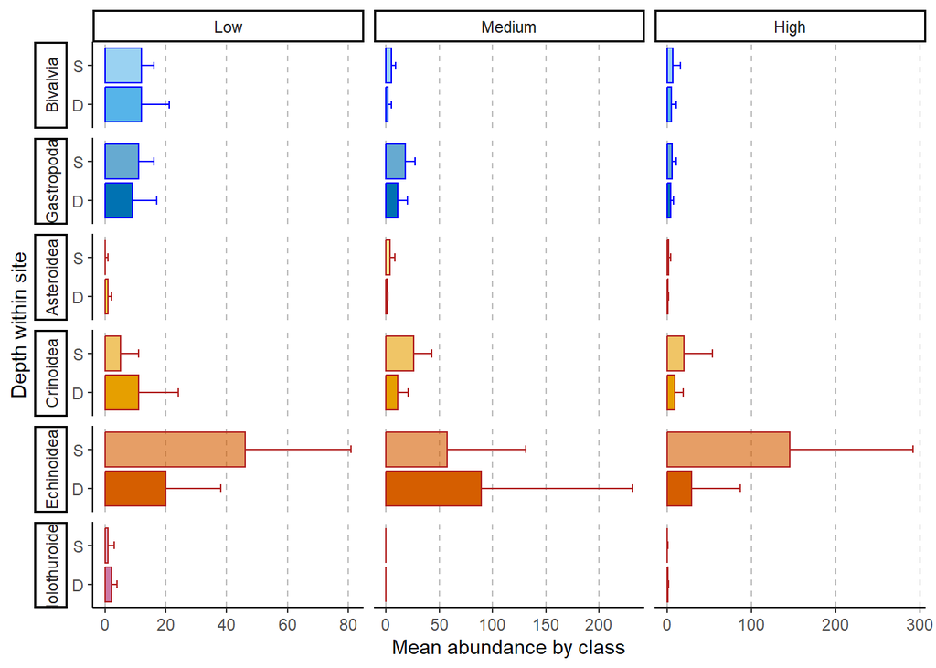

```r
ggplot(subset(inv_bar_pressure, inv_bar_pressure$class != "Ophiuroidea"),
       aes(x=depth, y=mean, fill=class, label=mean, color=phylum)) +
  geom_bar(aes(alpha=depth),position="dodge",stat="identity") +
  geom_errorbar(aes(ymin=mean, ymax=mean+sd), width=.2,
                 position="dodge")+
  facet_grid(class ~ pressure, scales = "free", switch = "y")+ # https://stackoverflow.com/questions/18046051/setting-individual-axis-limits-with-facet-wrap-and-scales-free-in-ggplot2
  theme_classic()+
  labs(x="Depth within site",
       y="Mean abundance by class")+
  scale_fill_manual(values=invPalette)+
  scale_color_manual(values=c("blue","firebrick"), guide ="none")+
  scale_alpha_manual(values=c(1,.6))+
  guides(fill="none", alpha= "none")+
  theme(panel.grid.major.x = element_line(color = "grey",
                                          size = 0.5,
                                          linetype = 2),
        strip.placement = "outside")+
    coord_flip()
```

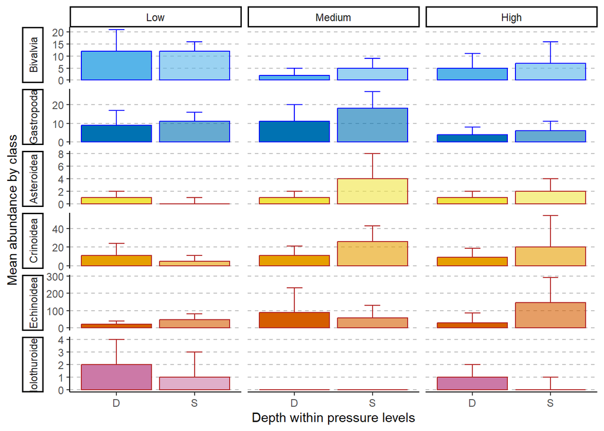

```r
ggplot(subset(inv_bar_pressure, inv_bar_pressure$class != "Ophiuroidea"),
       aes(x=depth, y=mean, fill=class, label=mean, color=phylum)) +
  geom_bar(aes(alpha=depth),position="dodge",stat="identity") +
  geom_errorbar(aes(ymin=mean, ymax=mean+sd), width=.2,
                 position="dodge")+
  facet_grid(class ~ pressure, scales = "free", switch = "y")+ # https://stackoverflow.com/questions/18046051/setting-individual-axis-limits-with-facet-wrap-and-scales-free-in-ggplot2
  theme_classic()+
  labs(x="Depth within pressure levels",
       y="Mean abundance by class")+
  scale_fill_manual(values=invPalette)+
  scale_color_manual(values=c("blue","firebrick"), guide ="none")+
  scale_alpha_manual(values=c(1,.6))+
  guides(fill="none", alpha= "none")+
  theme(panel.grid.major.y = element_line(color = "grey",
                                          size = 0.5,
                                          linetype = 2),
        strip.placement = "outside")
```

Export plot

```r
ggsave("mol-ech_abundance_pressure_barplot.tiff",
       units = "in", width = 4, height = 6, dpi = 300, compression = 'lzw',
       path = here ("Multi-taxa_data","MollEchino","Output"))
```

Plot filled w/ colors by pressure

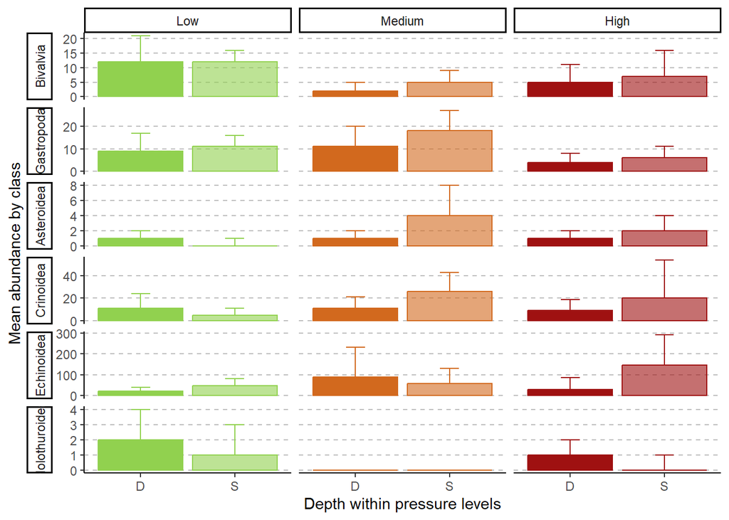

```r
ggplot(subset(inv_bar_pressure, inv_bar_pressure$class != "Ophiuroidea"),
       aes(x=depth, y=mean, fill=pressure, label=mean, color=pressure)) +
  geom_bar(aes(alpha=depth),position="dodge",stat="identity") +
  geom_errorbar(aes(ymin=mean, ymax=mean+sd), width=.2,
                 position="dodge")+
  facet_grid(class ~ pressure, scales = "free", switch = "y")+ # https://stackoverflow.com/questions/18046051/setting-individual-axis-limits-with-facet-wrap-and-scales-free-in-ggplot2
  theme_classic()+
  labs(x="Depth within pressure levels",
       y="Mean abundance by class")+
  scale_fill_manual(values= c(Low= rgb(0.57, 0.82, 0.31), Medium = "chocolate", High = "#9F1111"))+
  scale_color_manual(values= c(Low= rgb(0.57, 0.82, 0.31), Medium = "chocolate", High = "#9F1111"),  guide ="none")+
  scale_alpha_manual(values=c(1,.6))+
  guides(fill="none", alpha= "none")+
  theme(panel.grid.major.y = element_line(color = "grey",
                                          size = 0.5,
                                          linetype = 2),
        strip.placement = "outside")
```

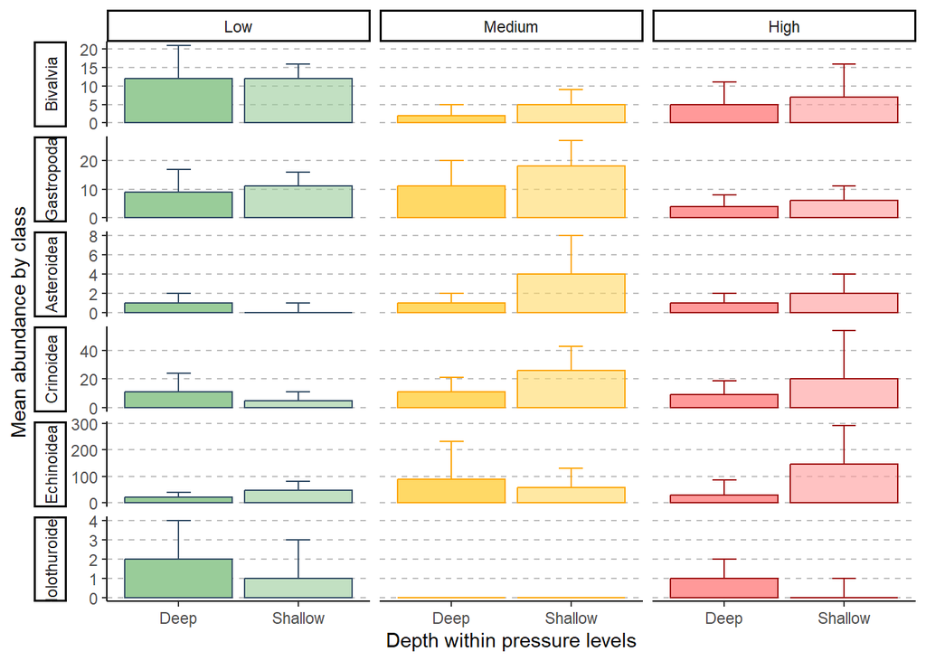

```r
ggplot(subset(inv_bar_pressure, inv_bar_pressure$class != "Ophiuroidea"),
       aes(x=depth, y=mean,
           fill=pressure,
           label=mean,
           color=pressure)) +
  geom_bar(aes(alpha=depth),
           position="dodge",
           stat="identity") +
  geom_errorbar(aes(ymin=mean, ymax=mean+sd),
                width=.2,
                position="dodge")+
  facet_grid(class ~ pressure,
             scales = "free",
             switch = "y")+ # https://stackoverflow.com/questions/18046051/setting-individual-axis-limits-with-facet-wrap-and-scales-free-in-ggplot2
  theme_classic()+
  labs(x="Depth within pressure levels",
       y="Mean abundance by class")+
  scale_x_discrete(labels = c("Deep", "Shallow"))+
  scale_fill_manual(values= c(Low= rgb(0.6, 0.8, 0.6),
                              Medium = rgb(1, 0.85, 0.4),
                              High = rgb(1,0.6,0.6)
                              )
                    )+
  scale_color_manual(values= c(Low= rgb(0.2, 0.3, 0.4),
                               Medium = rgb(0.99, 0.65, 0.04),
                               High = "#9F1111"),
                     guide ="none")+
  scale_alpha_manual(values=c(1,.6))+
  guides(fill="none", alpha= "none")+
  theme(panel.grid.major.y = element_line(color = "grey",
                                          size = 0.5,
                                          linetype = 2),
        strip.placement = "outside")
```

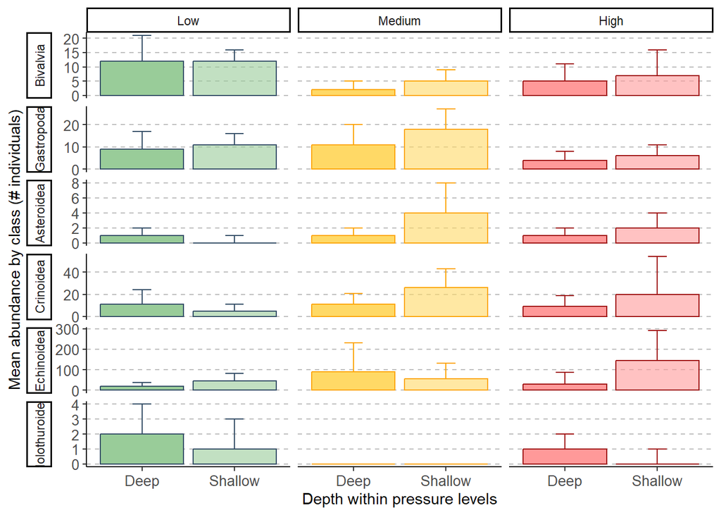

```r
ggplot(subset(inv_bar_pressure, inv_bar_pressure$class != "Ophiuroidea"),
       aes(x=depth, y=mean,
           fill=pressure,
           label=mean,
           color=pressure)) +
  geom_bar(aes(alpha=depth),
           position="dodge",
           stat="identity") +
  geom_errorbar(aes(ymin=mean, ymax=mean+sd),
                width=.2,
                position="dodge")+
  facet_grid(class ~ pressure,
             scales = "free",
             switch = "y")+ # https://stackoverflow.com/questions/18046051/setting-individual-axis-limits-with-facet-wrap-and-scales-free-in-ggplot2
  theme_classic()+
  labs(x="Depth within pressure levels",
       y="Mean abundance by class (# individuals)")+
  scale_x_discrete(labels = c("Deep", "Shallow"))+
  scale_fill_manual(values= c(Low= rgb(0.6, 0.8, 0.6),
                              Medium = rgb(1, 0.85, 0.4),
                              High = rgb(1,0.6,0.6)
                              )
                    )+
  scale_color_manual(values= c(Low= rgb(0.2, 0.3, 0.4),
                               Medium = rgb(0.99, 0.65, 0.04),
                               High = "#9F1111"),
                     guide ="none")+
  scale_alpha_manual(values=c(1,.6))+
  guides(fill="none", alpha= "none")+
  theme(axis.text = element_text(size = 10),
        panel.grid.major.y = element_line(color = "grey",
                                          size = 0.5,
                                          linetype = 2),
        strip.placement = "outside")
```

Export plot for poster

```r
ggsave("mol-ech_abundance_pressure_barplot_poster.tiff",
       units = "in", width = 4, height = 6, dpi = 300, compression = 'lzw',
       path = here ("Multi-taxa_data","MollEchino","Output"))
```